# GAM models

Justin Pomeranz

8/22/2023

# Generalized Additive Models for ice lake phenology

# Justin Pomeranz jpomeranz@coloradomesa.edu

# September 2023

### libraries

```r
library(tidyverse)
library(lme4)
library(lmerTest)
library(ggeffects)
library(broom)
library(mgcv)
library(gratia)
library(broom)
```

Custom function previously written by Bella Oleksy to calculate the number of days based on water year (beginning on October 1)

```r
# Custom function from Oleksy
# custom function to calculate julian-day of water year
hydro.day = function(x, start.month = 10L) {
  start.yr = year(x) - (month(x) < start.month)
  start.date = make_date(start.yr, start.month, 1L)
  as.integer(x - start.date + 1L)
}
```

### data

#### Note on the data

I copied the raw data from: https://github.com/afilazzola/IcePhenologyDatabase/blob/main/data/PhenologyData.csv#L6

When I tried to download the original csv file, excel was doing weird things with the date columns. This occurred even when I copied/pasted directly into excel, and changed the advanced settings for “text to columns” option.

I found a workaround:  
1. I copied the raw data from the github link above  
2. Pasted the raw values into notepad and saved as a `.txt` file  
3. read in the `.txt` file  
4. All dates correctly imported as `<date>` format.

#### Wrangle data

- Select the columns
- filter out appropriate lakes
- calculate “hydro day” (Julian day of water year, starting on Oct 1)
- filter years between 1927 to 2022
- Calculate ice duration days

Read in the lake phenology data from “other” lakes.

```r
## Non-Yellowstone lakes
non_ysl <- read_csv(here::here("scripts/other_phenology.txt"))

non_ysl <- non_ysl %>%
  # select necessary columns
  select(lake, lakecode, start_year, iceOn, iceOff, orig_duration) %>%
  # filter out lakes:
  filter(lakecode == "JK25"| # Lake Haukivesi
           lakecode == "JK02"| # Lake Kallavesi
           lakecode == "GW369"| # Lake Kallsjön
           lakecode == "JK03"| # Näsijärvi
           lakecode == "JK05"| # Päijänne
           lakecode == "JK40"| # Pielinen
           lakecode == "NG1" # Lake Baikal
  ) %>%
  # below is jp original
  # caluclate on and off julian dates for water year
  mutate(j_on_wy = hydro.day(iceOn),
         j_off_wy = hydro.day(iceOff)) %>%
  # filter out data only from 1927 to 2022
  filter(start_year >= 1927, start_year <=2022) %>%
  mutate(ice_days = j_off_wy - j_on_wy)
```

#### Modify yellowstone lake data

```r
# yellowstone data
ysl_ice <- read.csv(here::here("scripts/YSLoff.csv")) %>%
  #select(Year, IceOnDate, IceOffDate,) %>%
  mutate(lake = "yellowstone")

# modify data
ysl_ice <- ysl_ice %>%
  #unite(IceOnDate, c(IceOnDate, Year), sep = "-", remove = FALSE) %>%
  #unite(IceOffDate, c(IceOffDate, Year), sep = "-", remove = FALSE) %>%
  mutate(IceOnJulian_new = case_when(IceOnJulian > 365 ~ IceOnJulian - 365,
                                     TRUE ~ IceOnJulian)) %>%
  mutate(new_iceondate = ymd(parse_date_time(paste(Year, IceOnJulian_new), orders = "yj")),
         new_iceoffdate = ymd(parse_date_time(paste(Year, IceOffJulian), orders = "yj")),

         IceOn_fedDOY = hydro.day(new_iceondate),
         IceOff_fedDOY = hydro.day(new_iceoffdate))#,
#         ice_days = j_off_wy-j_on_wy)  #%>%
  # rename(start_year = Year) %>%
  # select(lake, start_year, j_on_wy, j_off_wy, ice_days)

#Get water-year for each ice phenology indicator separately, then join back together.
ysl_iceOn <- ysl_ice %>%
  select(new_iceondate, IceOn_fedDOY) %>%
  mutate(water_year = dataRetrieval::calcWaterYear(new_iceondate)) %>%
  filter(!new_iceondate=="1952-12-24") %>%
  arrange(water_year) %>%
  group_by(water_year) %>%
  slice_tail(n=1)

ysl_iceOn_old <- ysl_ice %>%
  select(new_iceondate, IceOn_fedDOY) %>%
  mutate(water_year = dataRetrieval::calcWaterYear(new_iceondate)) %>%
  filter(!new_iceondate=="1952-12-24")

ysl_iceOff <- ysl_ice %>%
  select(new_iceoffdate, IceOff_fedDOY, AnnualMax:SnowDepth) %>%
  mutate(water_year = dataRetrieval::calcWaterYear(new_iceoffdate))

ysl_ice_clean <- full_join(ysl_iceOn, ysl_iceOff, by="water_year") %>%
  mutate(iceDuration = IceOff_fedDOY-IceOn_fedDOY)

ysl_ice <- ysl_ice_clean %>%
  rename(start_year = water_year,
         j_on_wy = IceOn_fedDOY,
         j_off_wy = IceOff_fedDOY,
         ice_days = iceDuration) %>%
  mutate(lake = "yellowstone") %>%
  select(lake, start_year, j_on_wy, j_off_wy, ice_days)
```

#### combine the two data sets into `full_data`

```r
# combine data sets
full_data <- bind_rows(non_ysl, ysl_ice) %>%
  mutate(start_y_c = start_year - mean(start_year, na.rm = TRUE))
saveRDS(full_data,
        file = here::here("scripts/all_lake_data.rds"))
```

# GAMs

#### Function to fit GAMs

- Fit a GAM with specified `gam_formula`
- Make the following objects
  - model summaries
  - draw_plot
  - appraise model
- Return a list with the following:
  - `lake_name`
  - `mod` = model fit
  - `draw_plot` = results of the `draw()` function
  - `appraise` = results of the `apraise()` function

```r
gam_mod_fun <- function(data, gam_formula, lake_name){
  mod <- gam(gam_formula,
             family=Gamma(link="log"),
             data = data %>%
               filter(lake == lake_name),
             correlation = corCAR1(
               form = ~ start_year),
             method = "REML")
  mod_summary <- summary(mod)
  draw_plot <- draw(mod)
  app_plot <- appraise(mod)
  return(list(lake_name = lake_name,
              mod = mod,
              summary = mod_summary,
              draw_plot = draw_plot,
              appraise = app_plot))}
```

# Summary function

This function summarizes the GAM model fits and displays output in a “tidy” format

```r
gam_summary <- function(mydata, gam_formula, group_var) {
  group_var = enquo(group_var)

  mydata <- mydata %>%
    group_by(!!group_var) %>%
    nest()

  mydata %>%
    mutate(
      model = map(data,
                  ~(gam(
                    gam_formula,
                    family=Gamma(link="log"),
                    data = .,
                    correlation = corCAR1(
                      form = ~ start_year),
                    method = "REML"))))
}
```

# list of models

`for`-loop producing a list of the summary outputs for each lake.

Run the loop for each response variable

### ice on

```r
lake_names <- full_data %>%
  pull(lake) %>%
  unique()

ice_on_list <- list()
for (lake in 1:length(lake_names)){
  lake_name = lake_names[lake]
  response_mod <- gam_mod_fun(full_data, j_on_wy~s(start_year), lake_name)
  ice_on_list[[lake]] <- response_mod
}
names(ice_on_list) <- lake_names
```

### ice off

```r
ice_off_list <- list()
for (lake in 1:length(lake_names)){
  lake_name = lake_names[lake]
  response_mod <- gam_mod_fun(full_data, j_off_wy~s(start_year), lake_name)
  ice_off_list[[lake]] <- response_mod
}
names(ice_off_list) <- lake_names
```

### duration

```r
ice_days_list <- list()
for (lake in 1:length(lake_names)){
  lake_name = lake_names[lake]
  response_mod <- gam_mod_fun(full_data, ice_days~s(start_year), lake_name)
  ice_days_list[[lake]] <- response_mod
}
names(ice_days_list) <- lake_names
```

## Save list of lists

ice_response_list = list(ice_days_list ice_off_list ice_on_list)

```r
ice_response_list = list(duration = ice_days_list,
                         off_date = ice_off_list,
                         on_date = ice_on_list)
saveRDS(ice_response_list, file = here::here("scripts/ice_response_list.RDS"))
```

# print out results of baikal as example

```r
list(ice_days_list$baikal,
     ice_off_list$baikal,
     ice_on_list$baikal)
```

```
## [[1]]
## [[1]]$lake_name
## [1] "baikal"
##
## [[1]]$mod
##
## Family: Gamma
## Link function: log
##
## Formula:
## ice_days ~ s(start_year)
##
## Estimated degrees of freedom:
## 1  total = 2
##
## REML score: 397.3773
##
## [[1]]$summary
##
## Family: Gamma
## Link function: log
##
## Formula:
## ice_days ~ s(start_year)
##
## Parametric coefficients:
##             Estimate Std. Error t value Pr(>|t|)
## (Intercept)  4.67784    0.01491   313.7   <2e-16 ***
## ---
## Signif. codes:  0 '***' 0.001 '**' 0.01 '*' 0.05 '.' 0.1 ' ' 1
##
## Approximate significance of smooth terms:
##                 edf Ref.df     F p-value
## s(start_year) 1.002  1.003 5.857  0.0175 *
## ---
## Signif. codes:  0 '***' 0.001 '**' 0.01 '*' 0.05 '.' 0.1 ' ' 1
##
## R-sq.(adj) =  0.0486   Deviance explained = 5.77%
## -REML = 397.38  Scale est. = 0.020904  n = 94
##
## [[1]]$draw_plot
```

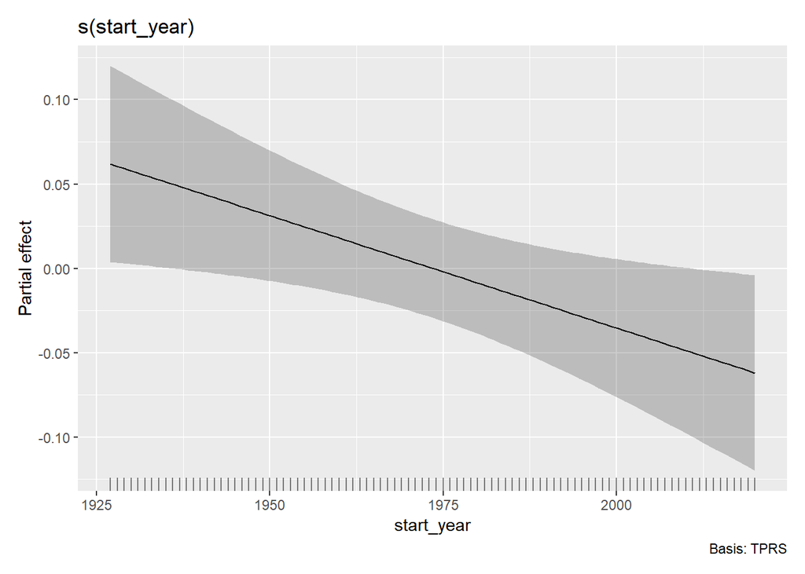

```
##
## [[1]]$appraise
```

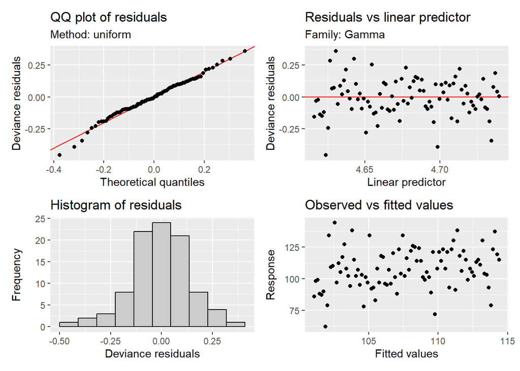

```
##
##
## [[2]]
## [[2]]$lake_name
## [1] "baikal"
##
## [[2]]$mod
##
## Family: Gamma
## Link function: log
##
## Formula:
## j_off_wy ~ s(start_year)
##
## Estimated degrees of freedom:
## 6.74  total = 7.74
##
## REML score: 334.869
##
## [[2]]$summary
##
## Family: Gamma
## Link function: log
##
## Formula:
## j_off_wy ~ s(start_year)
##
## Parametric coefficients:
##             Estimate Std. Error t value Pr(>|t|)
## (Intercept) 5.369099   0.003419    1570   <2e-16 ***
## ---
## Signif. codes:  0 '***' 0.001 '**' 0.01 '*' 0.05 '.' 0.1 ' ' 1
##
## Approximate significance of smooth terms:
##                 edf Ref.df     F p-value
## s(start_year) 6.737  7.852 3.747 0.00108 **
## ---
## Signif. codes:  0 '***' 0.001 '**' 0.01 '*' 0.05 '.' 0.1 ' ' 1
##
## R-sq.(adj) =  0.228   Deviance explained = 28.8%
## -REML = 334.87  Scale est. = 0.0010987  n = 94
##
## [[2]]$draw_plot
```

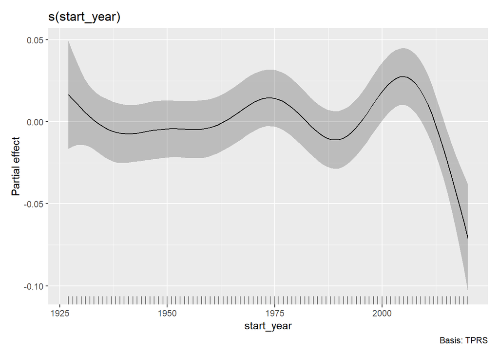

```
##
## [[2]]$appraise
```

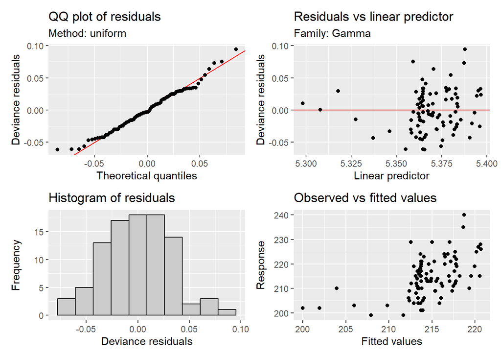

```
##
##
## [[3]]
## [[3]]$lake_name
## [1] "baikal"
##
## [[3]]$mod
##
## Family: Gamma
## Link function: log
##
## Formula:
## j_on_wy ~ s(start_year)
##
## Estimated degrees of freedom:
## 1  total = 2
##
## REML score: 355.5742
##
## [[3]]$summary
##
## Family: Gamma
## Link function: log
##
## Formula:
## j_on_wy ~ s(start_year)
##
## Parametric coefficients:
##             Estimate Std. Error t value Pr(>|t|)
## (Intercept) 4.673286   0.009593   487.2   <2e-16 ***
## ---
## Signif. codes:  0 '***' 0.001 '**' 0.01 '*' 0.05 '.' 0.1 ' ' 1
##
## Approximate significance of smooth terms:
##               edf Ref.df     F  p-value
## s(start_year)   1  1.001 11.61 0.000972 ***
## ---
## Signif. codes:  0 '***' 0.001 '**' 0.01 '*' 0.05 '.' 0.1 ' ' 1
##
## R-sq.(adj) =  0.104   Deviance explained = 11.2%
## -REML = 355.57  Scale est. = 0.0086504  n = 94
##
## [[3]]$draw_plot
```

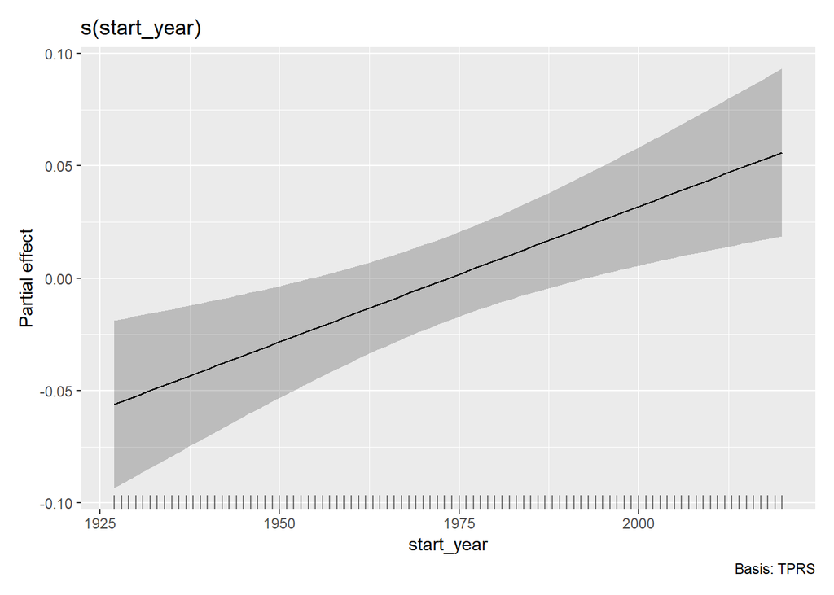

```
##
## [[3]]$appraise
```

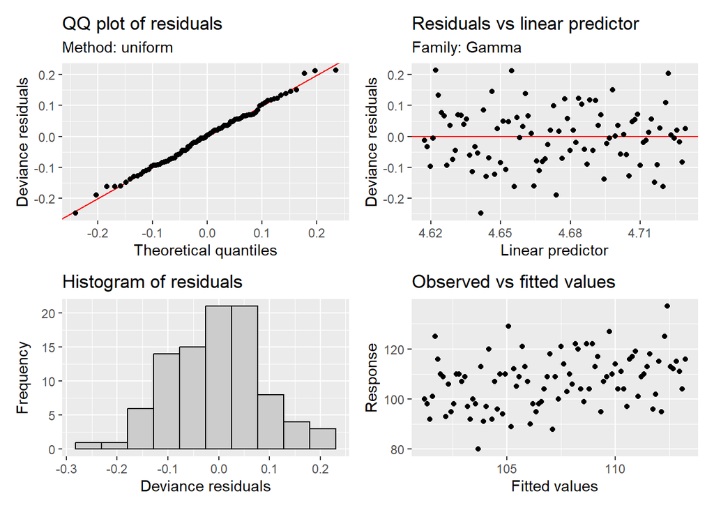

## Yellowstone

```r
list(ice_days_list$yellowstone,
     ice_off_list$yellowstone,
     ice_on_list$yellowstone)
```

```
## [[1]]
## [[1]]$lake_name
## [1] "yellowstone"
##
## [[1]]$mod
##
## Family: Gamma
## Link function: log
##
## Formula:
## ice_days ~ s(start_year)
##
## Estimated degrees of freedom:
## 1.26  total = 2.26
##
## REML score: 258.1298
##
## [[1]]$summary
##
## Family: Gamma
## Link function: log
##
## Formula:
## ice_days ~ s(start_year)
##
## Parametric coefficients:
##             Estimate Std. Error t value Pr(>|t|)
## (Intercept)  4.98793    0.01516   328.9   <2e-16 ***
## ---
## Signif. codes:  0 '***' 0.001 '**' 0.01 '*' 0.05 '.' 0.1 ' ' 1
##
## Approximate significance of smooth terms:
##                edf Ref.df    F p-value
## s(start_year) 1.26  1.477 0.07   0.853
##
## R-sq.(adj) =  -0.0101   Deviance explained = 1.12%
## -REML = 258.13  Scale est. = 0.013568  n = 59
##
## [[1]]$draw_plot
```

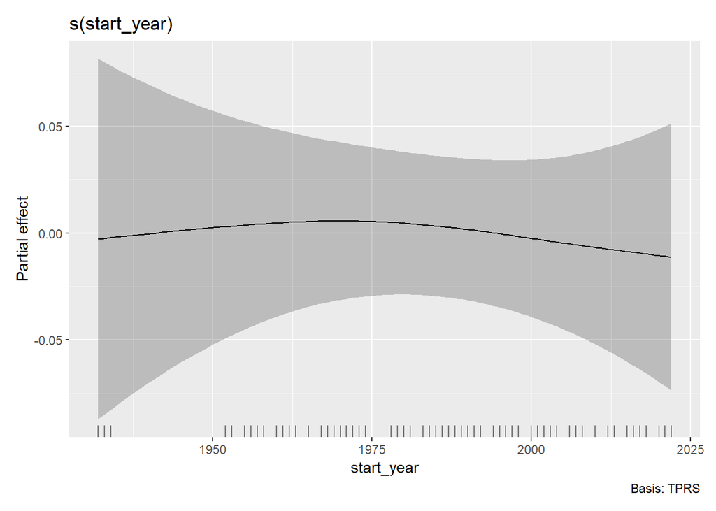

```
##
## [[1]]$appraise
```

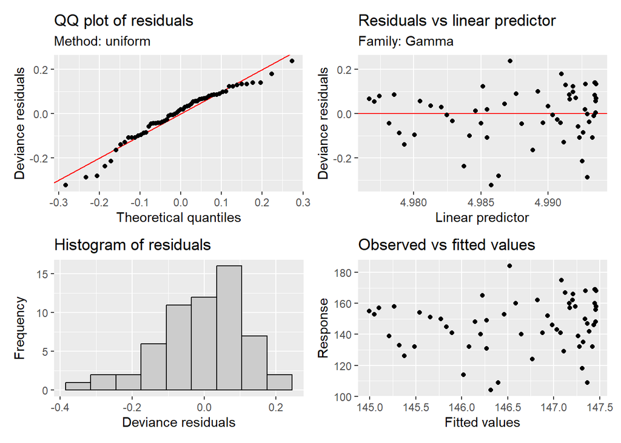

```
##
##
## [[2]]
## [[2]]$lake_name
## [1] "yellowstone"
##
## [[2]]$mod
##
## Family: Gamma
## Link function: log
##
## Formula:
## j_off_wy ~ s(start_year)
##
## Estimated degrees of freedom:
## 1  total = 2
##
## REML score: 315.4397
##
## [[2]]$summary
##
## Family: Gamma
## Link function: log
##
## Formula:
## j_off_wy ~ s(start_year)
##
## Parametric coefficients:
##             Estimate Std. Error t value Pr(>|t|)
## (Intercept) 5.457252   0.004349    1255   <2e-16 ***
## ---
## Signif. codes:  0 '***' 0.001 '**' 0.01 '*' 0.05 '.' 0.1 ' ' 1
##
## Approximate significance of smooth terms:
##               edf Ref.df     F p-value
## s(start_year)   1  1.001 0.008    0.93
##
## R-sq.(adj) =  -0.0121   Deviance explained = 0.00991%
## -REML = 315.44  Scale est. = 0.001589  n = 84
##
## [[2]]$draw_plot
```

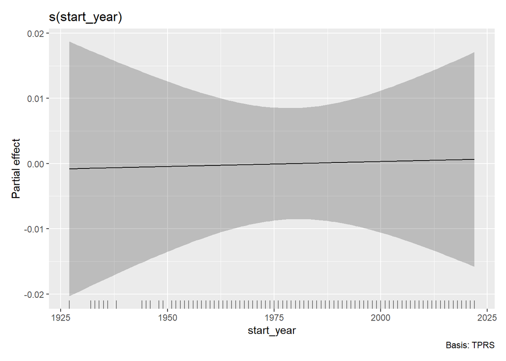

```
##
## [[2]]$appraise
```

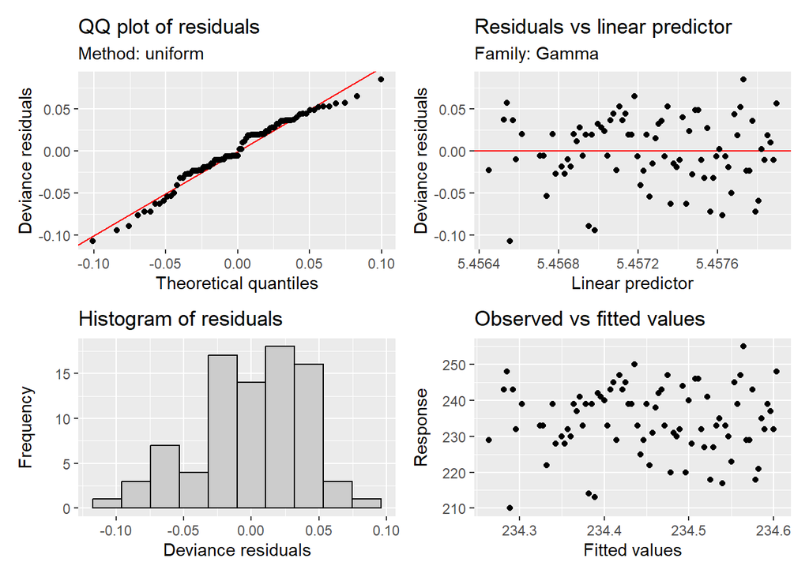

```
##
##
## [[3]]
## [[3]]$lake_name
## [1] "yellowstone"
##
## [[3]]$mod
##
## Family: Gamma
## Link function: log
##
## Formula:
## j_on_wy ~ s(start_year)
##
## Estimated degrees of freedom:
## 1  total = 2
##
## REML score: 235.7829
##
## [[3]]$summary
##
## Family: Gamma
## Link function: log
##
## Formula:
## j_on_wy ~ s(start_year)
##
## Parametric coefficients:
##             Estimate Std. Error t value Pr(>|t|)
## (Intercept)  4.46514    0.01688   264.5   <2e-16 ***
## ---
## Signif. codes:  0 '***' 0.001 '**' 0.01 '*' 0.05 '.' 0.1 ' ' 1
##
## Approximate significance of smooth terms:
##                 edf Ref.df     F p-value
## s(start_year) 1.001  1.002 0.028    0.87
##
## R-sq.(adj) =  -0.0167   Deviance explained = 0.0526%
## -REML = 235.78  Scale est. = 0.017105  n = 60
##
## [[3]]$draw_plot
```

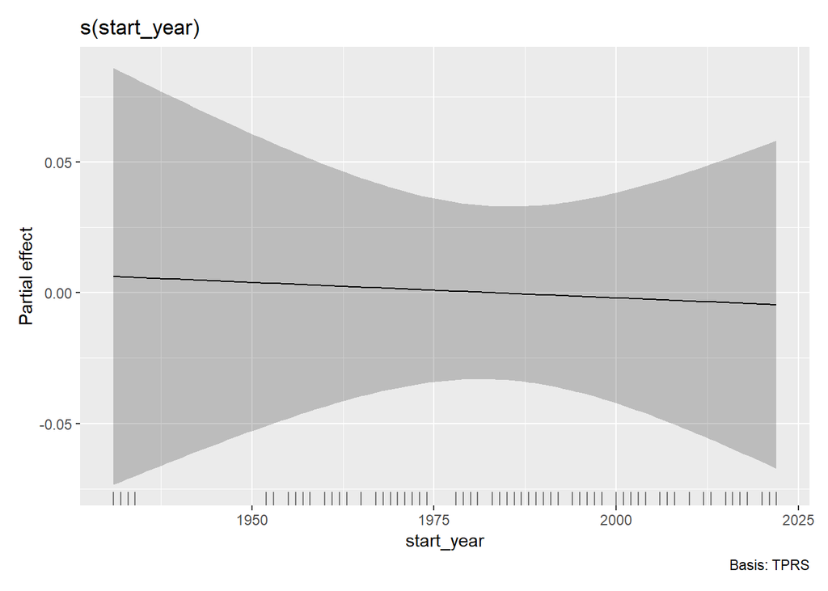

```
##
## [[3]]$appraise
```

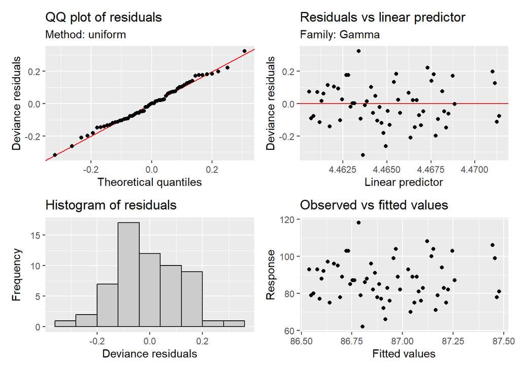

## plot results

**NOTE** these plots use the default `"gam"` option in `stat_smooth()`. They may differ slightly from the model fits used above.

# Ice duration figure

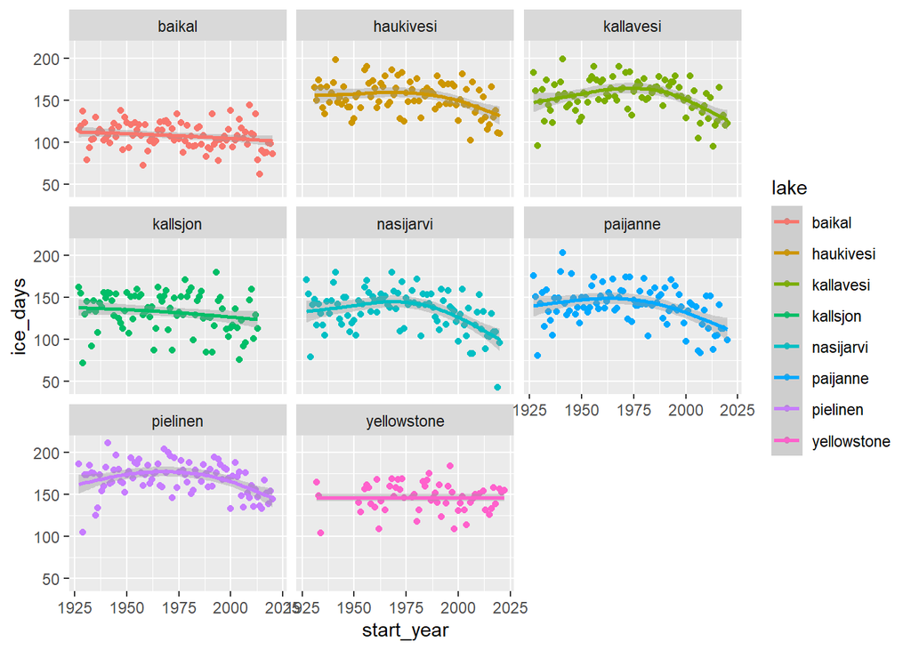

```r
ggplot(full_data,
       aes( x = start_year,
            y = ice_days,
            color = lake)) +
         geom_point() +
         stat_smooth(method = "gam") +
  facet_wrap(~lake)
```

# Ice-on figure

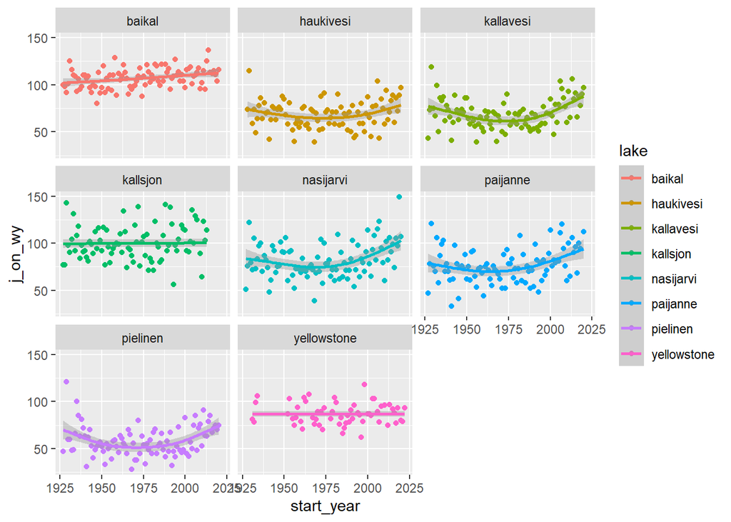

```r
ggplot(full_data,
       aes( x = start_year,
            y = j_on_wy,
            color = lake)) +
         geom_point() +
         stat_smooth(method = "gam") +
  facet_wrap(~lake)
```

# Ice-off figure

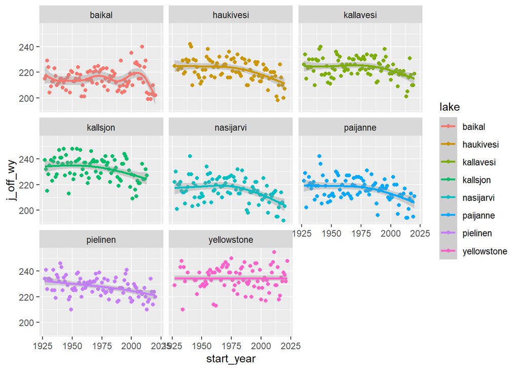

```r
ggplot(full_data,
       aes( x = start_year,
            y = j_off_wy,
            color = lake)) +
         geom_point() +
         stat_smooth(method = "gam") +
  facet_wrap(~lake)
```

## summary output of gams

**NOTE** edf in the summary output indicates the “wiggly-ness” of the model.  
* edf 1 == Linear * edf 2 == quadratic  
* edf 3 == cubic polynomial… * etc.

Most of the following models fall between edf 1 to edf 3.

Lake Baikal has edf 6 for ice-off.

The following summary outputs are arranged by p-value. Lakes at the top are “more significant”, and lakes lower down are less or non-significant.

Yellowstone is non-significant for all three responses. Most lakes have a significant response for most response variables.

### Ice-on

```r
off_stats <- gam_summary(full_data, j_on_wy~s(start_year), lake) %>%
  mutate(tidied = map(model, tidy)) %>%
  select(tidied) %>%
  unnest(tidied) %>%
  mutate(phenology = "ice_on") %>%
  arrange(lake_name, p.value)
off_stats
```

```
## # A tibble: 8 × 7
## # Groups:   lake [8]
##   lake        term            edf ref.df statistic   p.value phenology
##   <chr>       <chr>         <dbl>  <dbl>     <dbl>     <dbl> <chr>
## 1 kallavesi   s(start_year)  3.19   3.96    7.15   0.0000540 ice_on
## 2 pielinen    s(start_year)  3.24   4.03    5.73   0.000367  ice_on
## 3 nasijarvi   s(start_year)  2.77   3.45    5.76   0.000804  ice_on
## 4 baikal      s(start_year)  1.00   1.00   11.6    0.000972  ice_on
## 5 paijanne    s(start_year)  2.56   3.19    4.81   0.00326   ice_on
## 6 haukivesi   s(start_year)  2.59   3.23    2.67   0.0467    ice_on
## 7 kallsjon    s(start_year)  1.13   1.25    0.713  0.362     ice_on
## 8 yellowstone s(start_year)  1.00   1.00    0.0283 0.870     ice_on
```

Kallsjon and Yellowstone are non-significant

### Ice-off

```r
on_stats <- gam_summary(full_data, j_off_wy~s(start_year), lake) %>%
  mutate(tidied = map(model, tidy)) %>%
  select(tidied) %>%
  unnest(tidied) %>%
  arrange(lake_name, p.value) %>%
  mutate(phenology = "ice_off")
on_stats
```

```
## # A tibble: 8 × 7
## # Groups:   lake [8]
##   lake        term            edf ref.df statistic    p.value phenology
##   <chr>       <chr>         <dbl>  <dbl>     <dbl>      <dbl> <chr>
## 1 haukivesi   s(start_year)  2.70   3.37  10.3     0.00000464 ice_off
## 2 nasijarvi   s(start_year)  2.81   3.50   8.92    0.0000169  ice_off
## 3 pielinen    s(start_year)  1.13   1.25  17.2     0.0000230  ice_off
## 4 paijanne    s(start_year)  2.58   3.21   7.96    0.0000700  ice_off
## 5 kallavesi   s(start_year)  2.93   3.65   5.88    0.000623   ice_off
## 6 baikal      s(start_year)  6.74   7.85   3.75    0.00108    ice_off
## 7 kallsjon    s(start_year)  2.28   2.85   5.40    0.00234    ice_off
## 8 yellowstone s(start_year)  1.00   1.00   0.00807 0.930      ice_off
```

Only Yellowstone is non-significant

### duration

```r
duration_stats <- gam_summary(full_data, ice_days~s(start_year), lake) %>%
  mutate(tidied = map(model, tidy)) %>%
  select(tidied) %>%
  unnest(tidied) %>%
  arrange(lake_name, p.value) %>%
  mutate(phenology = "ice_duration")
duration_stats
```

```
## # A tibble: 8 × 7
## # Groups:   lake [8]
##   lake        term            edf ref.df statistic    p.value phenology
##   <chr>       <chr>         <dbl>  <dbl>     <dbl>      <dbl> <chr>
## 1 nasijarvi   s(start_year)  3.09   3.84   10.3    0.00000171 ice_duration
## 2 kallavesi   s(start_year)  3.30   4.09    8.71   0.00000539 ice_duration
## 3 paijanne    s(start_year)  2.74   3.41    8.04   0.0000532  ice_duration
## 4 pielinen    s(start_year)  3.06   3.81    7.48   0.0000576  ice_duration
## 5 haukivesi   s(start_year)  3.00   3.73    6.10   0.000347   ice_duration
## 6 baikal      s(start_year)  1.00   1.00    5.86   0.0175     ice_duration
## 7 kallsjon    s(start_year)  1.81   2.25    2.82   0.0602     ice_duration
## 8 yellowstone s(start_year)  1.26   1.48    0.0699 0.853      ice_duration
```

### Code to export

The following is not run when the document is stitched. To export the results, you will need to copy/paste the code into the console

```r
bind_rows(on_stats, off_stats, duration_stats) %>%
  write_csv(here::here("scripts/gam_stat_table.csv"))
```

Kallsjon and Yellowstone are non-significant

## Full figure

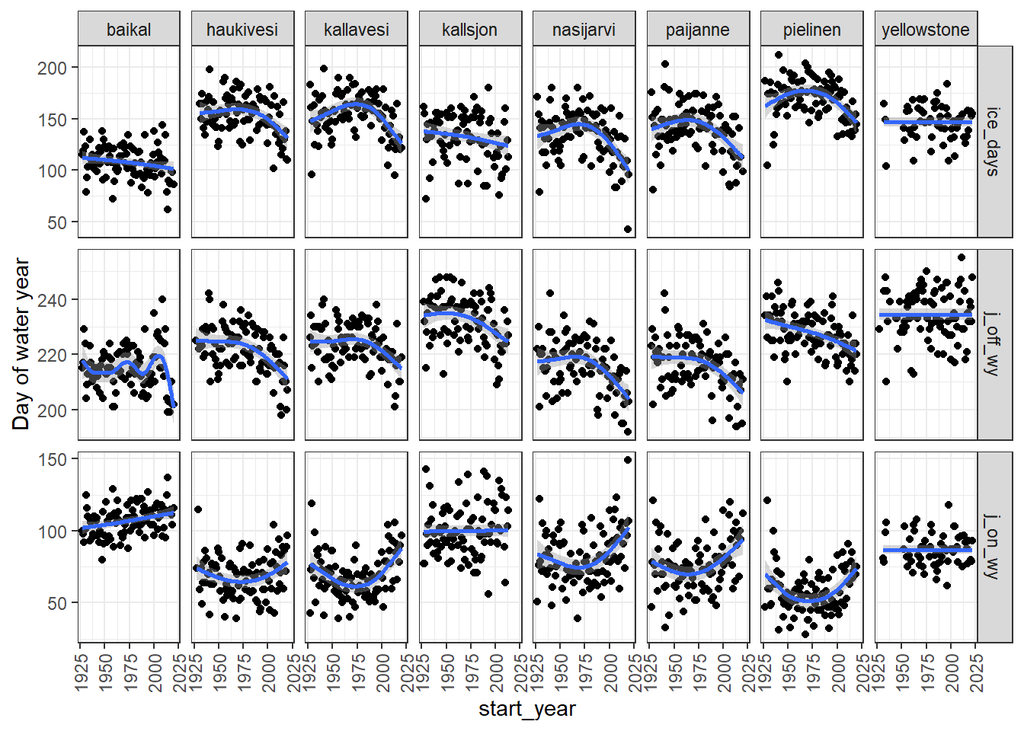

```r
full_data %>%
  select(lake, start_year, ice_days, j_on_wy, j_off_wy) %>%
  pivot_longer(ice_days:j_off_wy) %>%
  ggplot(aes(x = start_year,
             y = value)) +
  geom_point() +
  theme_bw() +
  facet_grid(name ~ lake, scales = "free_y") +
  geom_smooth(method = "gam") +
  labs(y = "Day of water year") +
  theme(axis.text.x = element_text(angle = 90, vjust = 0.5, hjust=1))
```

```r
# code to save image
# commenting out - trouble knitting with it in
# ggsave(here::here("scripts/full_fig_gams.png"),units = "in", height = 8, width = 8)
```

### Code to export high quality pdf

The following code is not run when the RMarkdown file is knit. To export the figure, you will need to copy/paste the below code into the console.

```r
hi_res <- full_data %>%
  select(lake, start_year, ice_days, j_on_wy, j_off_wy) %>%
  pivot_longer(ice_days:j_off_wy) %>%
  mutate(name = factor(name, levels = c("j_on_wy", "j_off_wy", "ice_days"))) %>%
  ggplot(aes(x = start_year,
             y = value)) +
  geom_point() +
  theme_bw() +
  facet_grid(name ~ lake, scales = "free_y") +
  geom_smooth(method = "gam") +
  labs(y = "Day of water year") +
  theme(axis.text.x = element_text(angle = 90, vjust = 0.5, hjust=1))

ggsave(filename = here::here("scripts/full_fig_hi-res.pdf"),
       plot = hi_res,
       dpi = 300)
```